# Search: Solving a Maze Using a Goal-based Agent

Student Name: Ethan Chou

I have used the following AI tools: OpenAI

I understand that my submission needs to be my own work: EC

## Instructions

Total Points: Undergrads 100 + 5 bonus / Graduate students 110

Complete this notebook. Use the provided notebook cells and insert additional code and markdown cells as needed. Submit the notebook file and the completely rendered notebook with all outputs as a HTML file.

## Introduction

The agent must use a map it is given to plan a path through the maze from the starting location $S$ to the goal location $G$. This is a planing exercise for a goal-based agent, so you do not need to implement an environment, just use the map to search for a path. Once the plan is made, the agent in a deterministic environment (i.e., the transition function is deterministic with the outcome of each state/action pair fixed and no randomness) can just follow the path and does not need to care about the percepts. This is also called an **[open-loop system](https://en.wikipedia.org/wiki/Open-loop_controller).** The execution phase is trivial and can be executed using a model-based reflex agent that ignores all percepts and just follows the plan. We do not implement it in this exercise.

Given that the agent has a complete and correct map, the environment is **fully observable, discrete, deterministic, and known.** Remember:

- **Fully observable** means that the agent can see its state and what the available actions are. That means the **percepts contain the complete current state.**

Here, during planning, the agent always sees its x and y coordinates on the map and also seeks when it has reached the goal state.

- **Discrete** means that we have a **finite set of states.** The maze has a finite set

of squares the agent can be in.

- **Deterministic** means that the **transition function contains no randomness.** An action in a state will always produce the same result. Going south from the start state always will lead to the same square.
- **Know** means that the agent **knows the complete transition function.** The

agent has the map and therefore knows how its position changes when it walks in a direction.

Tree search algorithm implementations that you find online typically come from data structures courses and have a different aim than AI tree search. These algorithms assume that you already have a tree in memory. We are interested in dynamically creating a search tree with the aim of finding a good/the best path from the root note to the goal state. Follow the pseudo code presented in the text book (and replicated in the slides) closely. Ideally, we would like to search only a small part of the maze, i.e., create a search tree with as few nodes as possible.

Several mazes for this exercise are stored as text files. Here is the small example maze:

```python
with open("small_maze.txt", "r") as f:
    maze_str = f.read()
print(maze_str)
```

```
XXXXXXXXXXXXXXXXXXXXXX
X XX        X X      X
X    XXXXXX X XXXXXX X
XXXXXX     S  X      X
X    X XXXXXX XX XXXXX
X XXXX X         X   X
X        XXX XXX   X X
XXXXXXXXXX    XXXXXX X
XG         XX        X
XXXXXXXXXXXXXXXXXXXXXX
```

## Parsing and pretty printing the maze

The maze can also be displayed in color using code in the module maze_helper.py. The code parses the string representing the maze and converts it into a `numpy` 2d array which you can use in your implementation. Position are represented as a 2-tuple of the form `(row, col)`.

```python
import maze_helper as mh

maze = mh.parse_maze(maze_str)

# look at a position in the maze by subsetting the 2d array
print("Position(0,0):", maze[0, 0])

# there is also a helper function called `look(maze, pos)` available
# which uses a 2-tuple for the position.
print("Position(8,1):", mh.look(maze, (8, 1)))
```

```
Position(0,0): X
Position(8,1): G
```

A helper function to visualize the maze is also available.

```python
%matplotlib inline
%config InlineBackend.figure_format = 'retina'
# use higher resolution images in notebooks

mh.show_maze(maze)
```

Find the `(x,y)` position of the start and the goal using the helper function `find_pos()`

```python
print("Start location:", mh.find_pos(maze, what = "S"))
print("Goal location:", mh.find_pos(maze, what = "G"))
```

```
Start location: (3, 11)
Goal location: (8, 1)
```

Helper function documentation.

```python
help(mh)
```

```
Help on module maze_helper:

NAME
    maze_helper

DESCRIPTION
    Code for the Maze Assignment by Michael Hahsler
    Usage:
        import maze_helper as mh
        mh.show_some_mazes()

FUNCTIONS
    find_pos(maze, what='S')
        Find start/goal in a maze and returns the first one.
        Caution: there is no error checking!

        Parameters:
        maze: a array with characters prodced by parse_maze()
        what: the letter to be found ('S' for start and 'G' for goal)

        Returns:
        a tupple (x, y) for the found position.

    look(maze, pos)
        Look at the label of a square with the position as an array of the form (x, y).

    parse_maze(maze_str)
        Convert a maze as a string into a 2d numpy array

    show_maze(maze, fontsize=10)
        Display a (parsed) maze as an image.

    welcome()
        Welcome message.

FILE
    c:\users\ethan\smu artificial intelligence\maze_helper.py
```

You will need to make a local copy of the module file maze_helper.py in the same folder where your notebook is.

## Tree structure

Here is an implementation of the basic node structure for the search algorithms (see Fig 3.7 on page 73). I have added a method that extracts the path from the root node to the current node. It can be used to get the path when the search is completed.

```python
class Node:
    def __init__(self, pos, parent, action, cost):
        self.pos = tuple(pos)    # the state; positions are (row,col)
        self.parent = parent     # reference to parent node. None means root node.
        self.action = action     # action used in the transition function (root node has None)
        self.cost = cost         # for uniform cost this is the depth. It is also g(n) for A* search

    def __str__(self):
        return f"Node - pos = {self.pos}; action = {self.action}; cost = {self.cost}"

    def get_path_from_root(self):
        """returns nodes on the path from the root to the current node."""
        node = self
        path = [node]

        while not node.parent is None:
            node = node.parent
            path.append(node)

        path.reverse()

        return(path)
```

If needed, then you can add more fields to the class like the heuristic value $h(n)$ or $f(n)$.

Examples for how to create and use a tree and information on memory management can be found here.

# Tasks

The goal is to:

1. Implement the following search algorithms for solving different mazes:
   - Breadth-first search (BFS)
   - Depth-first search (DFS)
   - Greedy best-first search (GBFS)
   - A* search
2. Run each of the above algorithms on the
   - small maze,
   - medium maze,
   - large maze,
   - open maze,
   - wall maze,
   - loops maze,
   - empty maze, and
   - empty 2_maze.
3. For each problem instance and each search algorithm, report the following in a table:
   - The solution and its path cost
   - Total number of nodes expanded
   - Maximum tree depth
   - Maximum size of the frontier
4. Display each solution by marking every maze square (or state) visited and the squares on the final path.

## General [10 Points]

1. Make sure that you use the latest version of this notebook.
2. Your implementation can use libraries like math, numpy, scipy, but not libraries that implement intelligent agents or complete search algorithms. Try to keep the code simple! In this course, we want to learn about the algorithms and we often do not need to use object-oriented design.
3. You notebook needs to be formatted professionally.
   - Add additional markdown blocks for your description, comments in the code, add tables and use mathplotlib to produce charts where appropriate
   - Do not show debugging output or include an excessive amount of output.
   - Check that your PDF file is readable. For example, long lines are cut off in the PDF file. You don't have control over page breaks, so do not worry about these.
4. Document your code. Add a short discussion of how your implementation works and your design choices.

## Task 1: Defining the search problem and determining the problem size [10 Points]

Define the components of the search problem:

- Initial state
- Actions
- Transition model
- Goal state
- Path cost

Use verbal descriptions, variables and equations as appropriate.

*Note:* You can swich the next block from code to Markdown and use formating.

- Initial state: cell "S"
- Action: Move from one cell to the next cell
- Transition: If the agent moves from cell X to cell Y, its new location is cell Y
- Goal state: cell "G"
- Path cost: Each step has a cost of 1

Give some estimates for the problem size:

- $n$: state space size
- $d$: depth of the optimal solution
- $m$: maximum depth of tree
- $b$: maximum branching factor

Describe how you would determin these values for a given maze.

```python
# Your answer goes here
```

- n: The state space size is the total number of possible states of the maze. For a maze with no walls this would be MxN where M is the number of rows and N is the number of columns. Otherwise, the state space would depend on the size, walls, and starting/end cells of the maze
- d: The number of steps from the starting cell to the goal cell. The number of steps varies with the size of the maze. This can be calculated by counting the number of nodes from the start to the end node in the path
- m: The largest distance from the starting cell to the goal cell or a dead end.
- b: The maximum branching factor is 4 because there are four possible neighbors that can be explored from a given node, which is North, South, East, and West.

## Task 2: Uninformed search: Breadth-first and depth-first [40 Points]

Implement these search strategies. Follow the pseudocode in the textbook/slides. You can use the tree structure shown above to extract the final path from your solution.

Read the following **important notes** carefully:

- You can find maze solving implementations online that use the map to store information. While this is an effective idea for this two-dimensional navigation problem, it typically cannot be used for other search problems. Therefore, follow the textbook and **do not store information in the map.** Only store information in the tree created during search, and use the `reached` and `frontier` data structures where appropriate.
- DSF behavior can be implemented using the BFS tree search algorithm and simply changing the order in which the frontier is expanded (this is equivalent to best-first search with path length as the criterion to expand the next node). However, this would be a big mistake since it combines the bad space complexity of BFS with the bad time complexity of DFS! **To take advantage of the significantly smaller memory footprint of DFS, you need to implement DFS in a different way without a `reached` data structure (often also called `visited` or `explored`) and by releasing the memory for nodes that are not needed anymore.**
- Since the proper implementation of DFS does not use a `reached` data structure, redundant path checking abilities are limited to cycle checking.

You need to implement **cycle checking since DSF is incomplete (produces an infinite loop) if cycles cannot be prevented.** You will see in your experiments that cycle checking in open spaces is challenging.

```python
def expand_node(maze, current_node, frontier, reached, actions, max_depth):
    for action in actions:
        # Calculate the next position
        row_offset, col_offset = actions[action]
        next_pos = (current_node.pos[0] + row_offset, current_node.pos[1] + col_offset)
        # Check if the move is within bounds and not a wall
        if 0 <= next_pos[0] < len(maze) and 0 <= next_pos[1] < len(maze[0]) and maze[next_pos[0]][next_pos[1]] != "X":
            # Create the next node
            next_node = Node(next_pos, current_node, action, current_node.cost + 1)
            # Check if the next node is the goal
            if maze[next_pos[0]][next_pos[1]] == "G":
                max_depth = max(max_depth, next_node.cost)
                return next_node, True, frontier, reached, max_depth
            # If the next position is not reached
            if next_pos not in reached:
                reached.append(next_pos)
                frontier.append(next_node)
                # Update max depth
                max_depth = max(max_depth, next_node.cost)

    return None, False, frontier, reached, max_depth

def breadth_first_search(maze, start, goal):
    max_depth = 0
    max_nodes_memory = 0
    max_frontier = 0
    nodes_expanded = 0

    # Create the starting node
    starting_node = Node(start, None, None, 0)

    # Frontier initialization
    frontier = [starting_node]
    reached = [starting_node.pos]

    # Actions
    actions = {"North": (-1, 0), "South": (1, 0), "East": (0, 1), "West": (0, -1)}

    # If agent is already at goal when starting
    if maze[starting_node.pos[0]][starting_node.pos[1]] == "G":
        max_depth = max(max_depth, next_node.cost)
        return starting_node.get_path_from_root(), starting_node.cost, max_depth, max_nodes_memory, max_frontier, nodes_expanded

    # Loop until the frontier is empty
    while frontier:
        # Update the maximum number of nodes in memory
        max_nodes_memory = max(max_nodes_memory, len(frontier))
        nodes_expanded += 1

        # Pop the node from the frontier
        current_node = frontier.pop(0)

        # Expand the current node
        next_node, found_goal, frontier, reached, max_depth = expand_node(maze, current_node, frontier, reached, actions, max_depth)

        if found_goal:
            max_depth = max(max_depth, next_node.cost)
            return next_node.get_path_from_root(), next_node.cost, max_depth, max_nodes_memory, max_frontier, nodes_expanded

        # Update max frontier size
        max_frontier = max(max_frontier, len(frontier))
    # Failure
    return None, None, max_depth, max_nodes_memory, max_frontier, nodes_expanded
```

```python
with open("small_maze.txt", "r") as f:
    maze_str = f.read()
maze = mh.parse_maze(maze_str)
print(maze_str)
mh.show_maze(maze)
result = breadth_first_search(maze, mh.find_pos(maze, "S"), mh.find_pos(maze, "G"))
for node in result[0]:
    if maze[node.pos] not in ["S", "G"]:
        maze[node.pos] = "P"
mh.show_maze(maze)
print('Path Cost:', result[1], '; Max Depth:', result[2], '; Max # of Nodes in Memory:', result[3], '; Max Frontier Size:', result[4], '; # of Nodes Expanded:', result[5])
```

```
XXXXXXXXXXXXXXXXXXXXXX
X XX        X X      X
X    XXXXXX X XXXXXX X
XXXXXX     S  X      X
X    X XXXXXX XX XXXXX
X XXXX X         X   X
X        XXX XXX   X X
XXXXXXXXXX    XXXXXX X
XG         XX        X
XXXXXXXXXXXXXXXXXXXXXX
```

```
Path Cost: 19 ; Max Depth: 19 ; Max # of Nodes in Memory: 9 ; Max Frontier Size: 9 ; # of Nodes Expanded: 90
```

```python
def expand_node_dfs(maze, current_node, frontier, actions, max_depth):
    for action in actions:
        # Calculate the next position
        row_offset, col_offset = actions[action]
        next_pos = (current_node.pos[0] + row_offset, current_node.pos[1] + col_offset)

        # Check if the move is within bounds and not a wall
        if 0 <= next_pos[0] < len(maze) and 0 <= next_pos[1] < len(maze[0]) and maze[next_pos[0]][next_pos[1]] != "X":
            # Check for cycle by ensuring the position is not already on the current path
            if not any(node.pos == next_pos for node in current_node.get_path_from_root()):
                if any(node.pos == next_pos for node in frontier):
                    # If the node is already in the frontier, remove the old instance
                    frontier = [node for node in frontier if node.pos != next_pos]
                # Create the next node
                next_node = Node(next_pos, current_node, action, current_node.cost + 1)
                # Check if the next node is the goal
                if maze[next_pos[0]][next_pos[1]] == "G":
                    max_depth = max(max_depth, next_node.cost)
                    return next_node, True, frontier, max_depth
                # Add the next node to the frontier
                frontier.append(next_node)

                # Update max depth
                max_depth = max(max_depth, next_node.cost)

    return None, False, frontier, max_depth

def depth_first_search(maze, start, goal):
    max_depth = 0
    max_nodes_memory = 0
    max_frontier = 0
    nodes_expanded = 0

    # Create the starting node
    starting_node = Node(start, None, None, 0)

    # Frontier initialization
    frontier = [starting_node]

    # Actions
    actions = {"North": (-1, 0), "South": (1, 0), "East": (0, 1), "West": (0, -1)}

    # If agent is already at goal when starting
    if maze[starting_node.pos[0]][starting_node.pos[1]] == "G":
        max_depth = max(max_depth, next_node.cost)
        return starting_node.get_path_from_root(), starting_node.cost, max_depth, max_nodes_memory, max_frontier, nodes_expanded

    # Loop until the frontier is empty
    while frontier:
        # Update the maximum number of nodes in memory
        max_nodes_memory = max(max_nodes_memory, len(frontier))
        nodes_expanded += 1

        # Pop the node from the frontier
        current_node = frontier.pop()

        # Expand the current node
        next_node, found_goal, frontier, max_depth = expand_node_dfs(maze, current_node, frontier, actions, max_depth)

        if found_goal:
            max_depth = max(max_depth, next_node.cost)
            return next_node.get_path_from_root(), next_node.cost, max_depth, max_nodes_memory, max_frontier, nodes_expanded

        # Update max frontier size
        max_frontier = max(max_frontier, len(frontier))

    # Failure
    return None, None, max_depth, max_nodes_memory, max_frontier, nodes_expanded
```

```
XXXXXXXXXXXXXXXXXXXXXX
X XX        X X      X
X    XXXXXX X XXXXXX X
XXXXXX     S  X      X
X    X XXXXXX XX XXXXX
X XXXX X         X   X
X        XXX XXX   X X
XXXXXXXXXX    XXXXXX X
XG         XX        X
XXXXXXXXXXXXXXXXXXXXXX
```

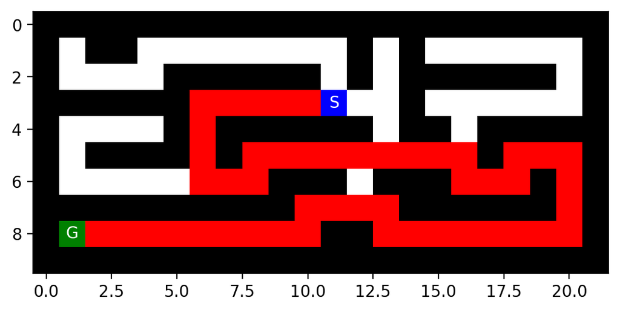

```
Path Cost: 49 ; Max Depth: 49 ; Max Node Memory: 6 ; Max Frontier: 6 ; Nodes Expanded: 59
```

```python
with open("small_maze.txt", "r") as f:
    maze_str = f.read()
maze = mh.parse_maze(maze_str)
print(maze_str)
mh.show_maze(maze)
result = depth_first_search(maze, mh.find_pos(maze, "S"), mh.find_pos(maze, "G"))
for node in result[0]:
    if maze[node.pos] not in ["S", "G"]:
        maze[node.pos] = "P"
mh.show_maze(maze)
print('Path Cost:', result[1], '; Max Depth:', result[2], '; Max Node Memory:', result[3], '; Max Frontier:', result[4], '; Nodes Expanded:', result[5])
```

How does BFS and DFS (without a reached data structure) deal with loops (cycles)?

# Discussion

BFS handles loops by recording all the nodes that it visited in a data structure, which allows it to check if a potential node has already been visited. This is fine in small mazes, but in larger mazes, the data structure can become too memory intensive. DFS, on the other hand, does not have a data structure that it can use to check if a potential node has already been visited. Instead, it uses cycle checking to prevent loops. The downside of DFS is that it can get stuck in an infinite loop and not be able to reach its target because it can revisit the same nodes indefinitely.

Are your implementations complete and optimal? Explain why. What is the time and space complexity of each of **your** implementations? Especially discuss the difference in space complexity between BFS and DFS.

# Discussion

My implementation for BFS is complete and optimal because it will return the fastest route to the goal, and since all step costs are equal. The time and space complexity of my implementation for BFS is O(b^d) where b is the branching factor (4 because there can be a potential of 4 neighbors), and d is the depth of the optimal solution.

My implementation for DFS is not optimal but it is complete. This is because while it will find the first path to the goal, that path may not be the most optimal path. The time complexity of DFS is O(b^m), where b is the branching factor, and m is the max depth (because it could take the longest path to the goal). The space complexity of DFS is O(b*m) because it does not store any records of visited nodes. It only knows the nodes of its current route.

This means that DFS is more efficient when space complexity is preferred.

## Task 3: Informed search: Implement greedy best-first search and A* search [20 Points]

You can use the map to estimate the distance from your current position to the goal using the Manhattan distance (see https://en.wikipedia.org/wiki/Taxicab_geometry) as a heuristic function. Both algorithms are based on Best-First search which requires only a small change from the BFS algorithm you have already implemented (see textbook/slides).

```python
# Your code goes here

def manhattan_distance(pos1, pos2):
    return (abs(pos1[0] - pos2[0]) + abs(pos1[1] - pos2[1]))

def expand_node_gbfs(maze, current_node, frontier, reached, goal, actions, max_depth):
    for action in actions:
        # Calculate the next position
        row_offset, col_offset = actions[action]
        next_pos = (current_node.pos[0] + row_offset, current_node.pos[1] + col_offset)
        # Check if the move is within bounds and not a wall
        if 0 <= next_pos[0] < len(maze) and 0 <= next_pos[1] < len(maze[0]) and maze[next_pos[0]][next_pos[1]] != "X":
            # Create the next node
            next_node = Node(next_pos, current_node, action, current_node.cost + 1)
            # Check if the next node is the goal
            if maze[next_pos[0]][next_pos[1]] == "G":
                max_depth = max(max_depth, next_node.cost)
                return next_node, True, frontier, reached, max_depth
            # If the next position is not reached
            if next_pos not in reached:
                reached.append(next_pos)
                frontier.append((manhattan_distance(next_pos, goal), next_node))
                # Update max depth
                max_depth = max(max_depth, next_node.cost)

    return None, False, frontier, reached, max_depth

def greedy_best_first_search(maze, start, goal):
    max_depth = 0
    max_nodes_memory = 0
    max_frontier = 0
    nodes_expanded = 0

    # Create the starting node
    starting_node = Node(start, None, None, 0)

    # Frontier initialization using manhattan distance
    frontier = [(manhattan_distance(starting_node.pos, goal), starting_node)]
    reached = [starting_node.pos]

    # Actions
    actions = {"North": (-1, 0), "South": (1, 0), "East": (0, 1), "West": (0, -1)}

    # If agent is already at goal when starting
    if maze[starting_node.pos[0]][starting_node.pos[1]] == "G":
        max_depth = max(max_depth, next_node.cost)
        return starting_node.get_path_from_root(), starting_node.cost, max_depth, max_nodes_memory, max_frontier, nodes_expanded

    # Loop until the frontier is empty
    while frontier:
        # Update the maximum number of nodes in memory
        max_nodes_memory = max(max_nodes_memory, len(frontier))
        nodes_expanded += 1

        # Pop the node from the frontier
        frontier.sort(key=lambda x: x[0])
        _, current_node = frontier.pop(0)

        # Expand the current node
        next_node, found_goal, frontier, reached, max_depth = expand_node_gbfs(maze, current_node, frontier, reached, goal, actions, max_depth)

        if found_goal:
            max_depth = max(max_depth, next_node.cost)
            return next_node.get_path_from_root(), next_node.cost, max_depth, max_nodes_memory, max_frontier, nodes_expanded

        # Update max frontier size
        max_frontier = max(max_frontier, len(frontier))

    # Failure
    return None, None, max_depth, max_nodes_memory, max_frontier, nodes_expanded
```

```
XXXXXXXXXXXXXXXXXXXXXX
X XX        X X      X
X    XXXXXX X XXXXXX X
XXXXXX     S  X      X
X    X XXXXXX XX XXXXX
X XXXX X         X   X
X        XXX XXX   X X
XXXXXXXXXX    XXXXXX X
XG         XX        X
XXXXXXXXXXXXXXXXXXXXXX
```

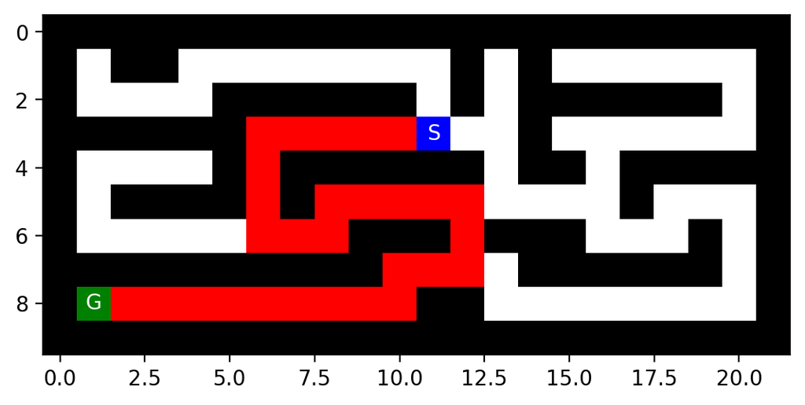

```
Path Cost: 29 ; Max Depth: 29 ; Max Node Memory: 5 ; Max Frontier: 5 ; Nodes Expanded: 39
```

```python
with open("small_maze.txt", "r") as f:
    maze_str = f.read()
maze = mh.parse_maze(maze_str)
print(maze_str)
mh.show_maze(maze)
result = greedy_best_first_search(maze, mh.find_pos(maze, "S"), mh.find_pos(maze, "G"))
for node in result[0]:
    if maze[node.pos] not in ["S", "G"]:
        maze[node.pos] = "P"
mh.show_maze(maze)
print('Path Cost:', result[1], '; Max Depth:', result[2], '; Max Node Memory:', result[3], '; Max Frontier:', result[4], '; Nodes Expanded:', result[5])
```

```python
# Your code goes here
def expand_node_abfs(maze, current_node, frontier, reached, goal, actions, max_depth):
    for action in actions:
        # Calculate the next position
        row_offset, col_offset = actions[action]
        next_pos = (current_node.pos[0] + row_offset, current_node.pos[1] + col_offset)
        # Check if the move is within bounds and not a wall
        if 0 <= next_pos[0] < len(maze) and 0 <= next_pos[1] < len(maze[0]) and maze[next_pos[0]][next_pos[1]] != "X":
            # Calculate g(n) for the next node
            new_cost = current_node.cost + 1
            # If this is a new position or a cheaper path to this position is found
            if next_pos not in reached or new_cost < reached[next_pos]:
                reached[next_pos] = new_cost
                next_node = Node(next_pos, current_node, action, new_cost)
                # Calculate f(n) = g(n) + h(n)
                f_value = new_cost + manhattan_distance(next_pos, goal)
                # Check if the next node is the goal
                if maze[next_pos[0]][next_pos[1]] == "G":
                    max_depth = max(max_depth, new_cost)
                    return next_node, True, frontier, reached, max_depth
                # Add the next node to the frontier with its f-value
                frontier.append((f_value, next_node))
                # Update max depth
                max_depth = max(max_depth, new_cost)

    return None, False, frontier, reached, max_depth

def a_breadth_first_search(maze, start, goal):
    max_depth = 0
    max_nodes_memory = 0
    max_frontier = 0
    nodes_expanded = 0

    # Create the starting node
    starting_node = Node(start, None, None, 0)

    # Frontier initialization using manhattan distance
    frontier = [(starting_node.cost + manhattan_distance(starting_node.pos, goal), starting_node)]
    reached = {starting_node.pos: starting_node.cost}

    # Actions
    actions = {"North": (-1, 0), "South": (1, 0), "East": (0, 1), "West": (0, -1)}

    # If agent is already at goal when starting
    if maze[starting_node.pos[0]][starting_node.pos[1]] == "G":
        max_depth = max(max_depth, new_cost)
        return starting_node.get_path_from_root(), starting_node.cost, max_depth, max_nodes_memory, max_frontier, nodes_expanded

    # Loop until the frontier is empty
    while frontier:
        # Update the maximum number of nodes in memory
        max_nodes_memory = max(max_nodes_memory, len(frontier))
        nodes_expanded += 1

        # Pop the node from the frontier
        frontier.sort(key=lambda x: x[0])
        _, current_node = frontier.pop(0)

        # Expand the current node
        next_node, found_goal, frontier, reached, max_depth = expand_node_abfs(maze, current_node, frontier, reached, goal, actions, max_depth)

        if found_goal:
            return next_node.get_path_from_root(), next_node.cost, max_depth, max_nodes_memory, max_frontier, nodes_expanded

        # Update max frontier size
        max_frontier = max(max_frontier, len(frontier))

    # Failure
    return None, None, max_depth, max_nodes_memory, max_frontier, nodes_expanded
```

```python
with open("small_maze.txt", "r") as f:
    maze_str = f.read()
maze = mh.parse_maze(maze_str)
print(maze_str)
mh.show_maze(maze)
result = a_breadth_first_search(maze, mh.find_pos(maze, "S"), mh.find_pos(maze, "G"))
for node in result[0]:
    if maze[node.pos] not in ["S", "G"]:
        maze[node.pos] = "P"
mh.show_maze(maze)
print('Path Cost:', result[1], '; Max Depth:', result[2], '; Max Node Memory:', result[3], '; Max Frontier:', result[4], '; Nodes Expanded:', result[5])
```

```
XXXXXXXXXXXXXXXXXXXXXX
X XX        X X      X
X    XXXXXX X XXXXXX X
XXXXXX     S  X      X
X    X XXXXXX XX XXXXX
X XXXX X         X   X
X        XXX XXX   X X
XXXXXXXXXX    XXXXXX X
XG         XX        X
XXXXXXXXXXXXXXXXXXXXXX
```

```
Path Cost: 19 ; Max Depth: 19 ; Max Node Memory: 8 ; Max Frontier: 8 ; Nodes Expanded: 53
```

Are your implementations complete and optimal? What is the time and space complexity?

# Discussion

The time complexity of my Greedy best-first search depends on the heuristic. In the worst case scenario, the time complexity is O(b^m), and in the best case scenario, the time complexity is O(bd). Since b is 4, this means that the time complexity for worst and best case scenario are O(4^m) and O(4d) respectively, where d is the depth and m is the max depth. The space complexity is O(4^m) at worst, and O(4m) at the best, where 4 = b. The Greedy best-first search is complete since it is able to find a solution, but it is not optimal since it may not always find the optimal solution, as sometimes going to the node closest may not end up resulting in the shortest path overall.

The time complexity and space complexity of my A* search is O(b^d) where b = 4 and d is the depth. It is both complete and optimal since it will find both a solution, and the solution will be optimal.

## Task 4: Comparison and discussion [20 Points]

Run experiments to compare the implemented algorithms.

How to deal with issues:

- Your implementation returns unexpected results: Try to debug and fix the code. Visualizing the maze, the current path and the frontier after every step is very helpful. If the code still does not work, then mark the result with an asterisk (*) and describe the issue below the table.
- Your implementation cannot consistently solve a specific maze and ends up in an infinite loop: Debug (likely your frontier and cycle checking for DFS are the issue). If it is a shortcoming of the algorithm/implementation, then put "N/A*" in the results table and describe why this is happening.

```
XXXXXXXXXXXXXXXXXXXXXX
X XX        X X      X
X    XXXXXX X XXXXXX X
XXXXXX     S  X      X
X    X XXXXXX XX XXXXX
X XXXX X         X   X
X        XXX XXX   X X
XXXXXXXXXX    XXXXXX X
XG         XX        X
XXXXXXXXXXXXXXXXXXXXXX
```

```
Path Cost: 19 ; Max Depth: 19 ; Max # of Nodes in Memory: 9 ; Max Frontier Size: 9 ; # of Nodes Expanded: 90
```

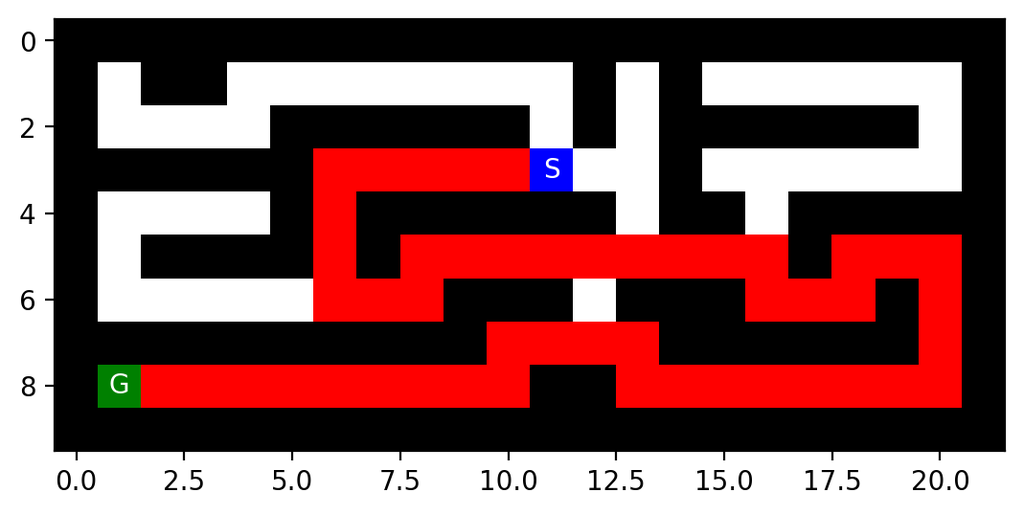

```
Path Cost: 49 ; Max Depth: 49 ; Max Node Memory: 6 ; Max Frontier: 6 ; Nodes Expanded: 59
```

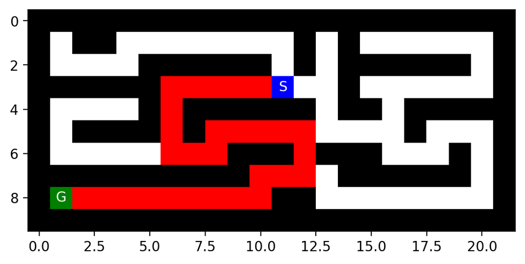

```
Path Cost: 29 ; Max Depth: 29 ; Max Node Memory: 5 ; Max Frontier: 5 ; Nodes Expanded: 39
```

```
Path Cost: 19 ; Max Depth: 19 ; Max Node Memory: 8 ; Max Frontier: 8 ; Nodes Expanded: 53
```

```python
# Add code
with open("small_maze.txt", "r") as f:
    maze_str = f.read()
maze = mh.parse_maze(maze_str)
print(maze_str)
mh.show_maze(maze)

# BFS
result = breadth_first_search(maze, mh.find_pos(maze, "S"), mh.find_pos(maze, "G"))
for node in result[0]:
    if maze[node.pos] not in ["S", "G"]:
        maze[node.pos] = "P"
mh.show_maze(maze)
print('Path Cost:', result[1], '; Max Depth:', result[2], '; Max # of Nodes in Memory:', result[3], '; Max Frontier Size:', result[4], '; # of Nodes Expanded:', result[5])

# DFS
resultdepth = depth_first_search(maze, mh.find_pos(maze, "S"), mh.find_pos(maze, "G"))
maze = mh.parse_maze(maze_str)
for node in resultdepth[0]:
    if maze[node.pos] not in ["S", "G"]:
        maze[node.pos] = "P"
mh.show_maze(maze)
print('Path Cost:', resultdepth[1], '; Max Depth:', resultdepth[2], '; Max Node Memory:', resultdepth[3], '; Max Frontier:', resultdepth[4], '; Nodes Expanded:', resultdepth[5])

# Greedy search
resultgreedy = greedy_best_first_search(maze, mh.find_pos(maze, "S"), mh.find_pos(maze, "G"))
maze = mh.parse_maze(maze_str)
for node in resultgreedy[0]:
    if maze[node.pos] not in ["S", "G"]:
        maze[node.pos] = "P"
mh.show_maze(maze)
print('Path Cost:', resultgreedy[1], '; Max Depth:', resultgreedy[2], '; Max Node Memory:', resultgreedy[3], '; Max Frontier:', resultgreedy[4], '; Nodes Expanded:', resultgreedy[5])

# a* search
resulta = a_breadth_first_search(maze, mh.find_pos(maze, "S"), mh.find_pos(maze, "G"))
maze = mh.parse_maze(maze_str)
for node in resulta[0]:
    if maze[node.pos] not in ["S", "G"]:
        maze[node.pos] = "P"
mh.show_maze(maze)
print('Path Cost:', resulta[1], '; Max Depth:', resulta[2], '; Max Node Memory:', resulta[3], '; Max Frontier:', resulta[4], '; Nodes Expanded:', resulta[5])
```

```python
from tabulate import tabulate

# Table
results = [
    ['BFS', result[1], result[2], result[3], result[4], result[5]],
    ['DFS', resultdepth[1], resultdepth[2], resultdepth[3], resultdepth[4], resultdepth[5]],
    ['Greedy Best-First', resultgreedy[1], resultgreedy[2], resultgreedy[3], resultgreedy[4], resultgreedy[5]],
    ['A* Search', resulta[1], resulta[2], resulta[3], resulta[4], resulta[5]]
]

columns = ['Algorithm', 'Path Cost', 'Max Depth', 'Max Nodes in Memory', 'Max Frontier Size', 'Nodes Expanded']

table = tabulate(results, headers=columns, tablefmt='grid')
print("Small Maze")
print(table)
```

```
Small Maze
+-------------------+-------------+-------------+-----------------------+---------------------+------------------+
| Algorithm         |   Path Cost |   Max Depth |   Max Nodes in Memory |   Max Frontier Size |   Nodes Expanded |
+===================+=============+=============+=======================+=====================+==================+
| BFS               |          19 |          19 |                     9 |                   9 |               90 |
+-------------------+-------------+-------------+-----------------------+---------------------+------------------+
| DFS               |          49 |          49 |                     6 |                   6 |               59 |
+-------------------+-------------+-------------+-----------------------+---------------------+------------------+
| Greedy Best-First |          29 |          29 |                     5 |                   5 |               39 |
+-------------------+-------------+-------------+-----------------------+---------------------+------------------+
| A* Search         |          19 |          19 |                     8 |                   8 |               53 |
+-------------------+-------------+-------------+-----------------------+---------------------+------------------+
```

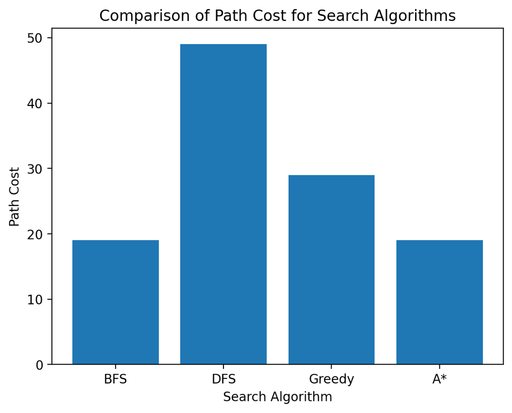

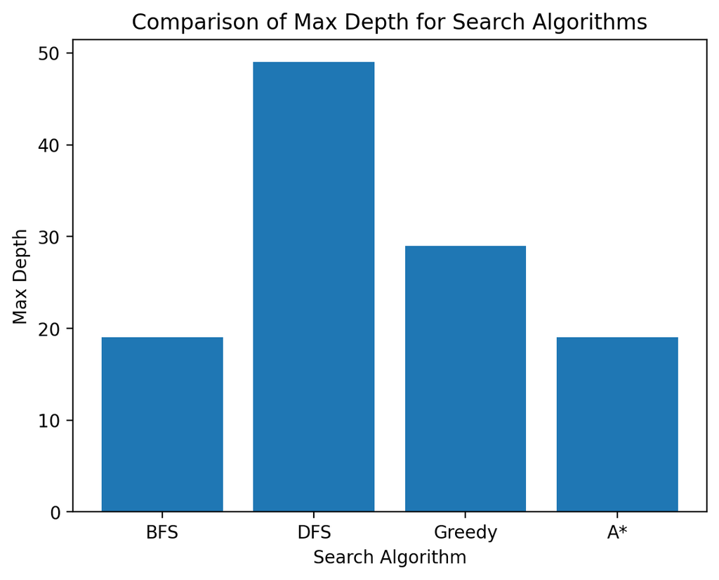

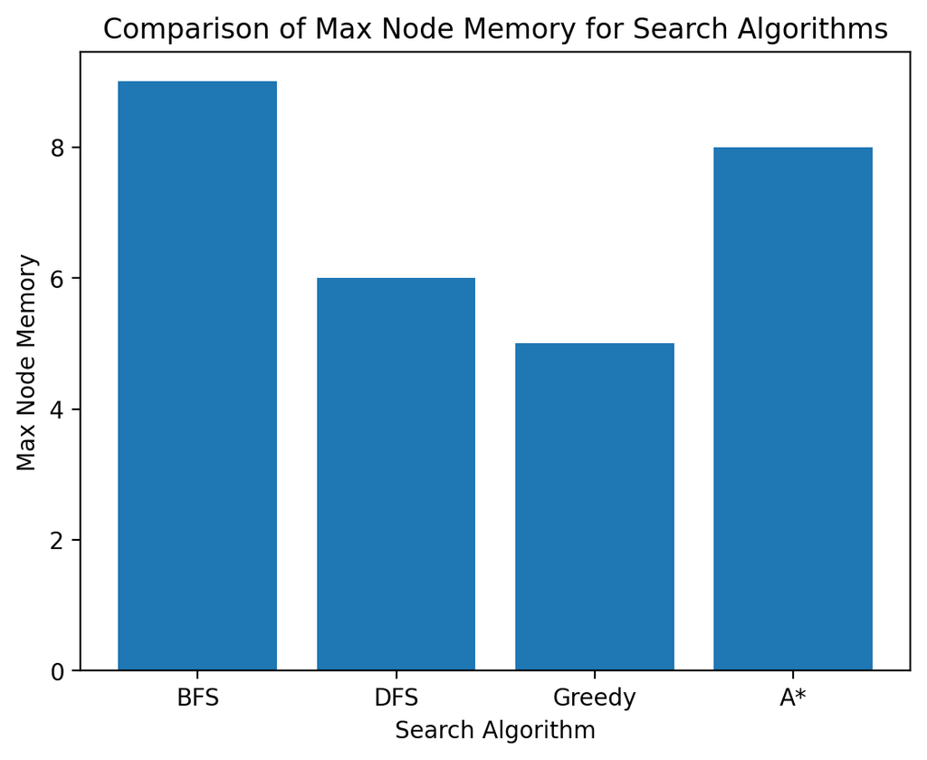

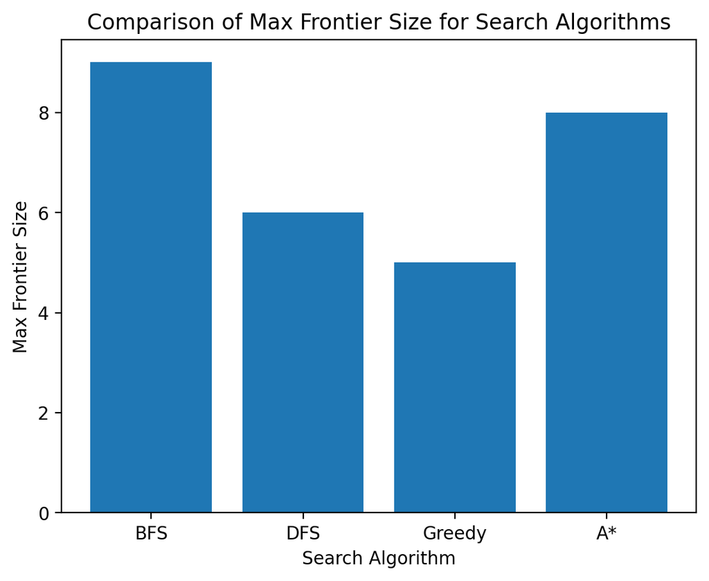

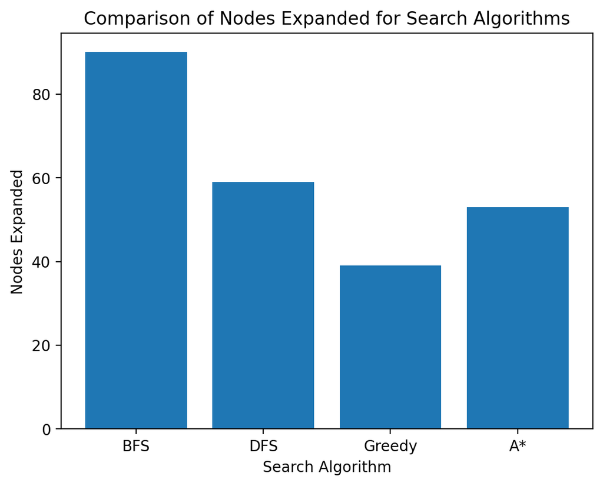

```python
import matplotlib.pyplot as plt
algorithms = ['BFS', 'DFS', 'Greedy', 'A*']

path_costs = [result[1], resultdepth[1], resultgreedy[1], resulta[1]]
max_depths = [result[2], resultdepth[2], resultgreedy[2], resulta[2]]
max_node_memories = [result[3], resultdepth[3], resultgreedy[3], resulta[3]]
max_frontiers = [result[4], resultdepth[4], resultgreedy[4], resulta[4]]
nodes_expanded = [result[5], resultdepth[5], resultgreedy[5], resulta[5]]

# Creating bar charts
metrics = {
    'Path Cost': path_costs,
    'Max Depth': max_depths,
    'Max Node Memory': max_node_memories,
    'Max Frontier Size': max_frontiers,
    'Nodes Expanded': nodes_expanded
}

# Generate the charts
for metric_name, values in metrics.items():
    plt.figure()
    plt.bar(algorithms, values)
    plt.title(f'Comparison of {metric_name} for Search Algorithms')
    plt.xlabel('Search Algorithm')
    plt.ylabel(metric_name)
    plt.show()
```

```
XXXXXXXXXXXXXXXXXXXXXXXXXXXXXXXXXXXX
X                                 SX
X XXXXXXXXXXXXXXXXXXXXXXX XXXXXXXX X
X XX   X   X      XXXXXXX   XX     X
X XX X X X X XXXX XXXXXXXXX XX XXXXX
X XX X X X X             XX XX     X
X XX X X X X X XXXX  XXX    XXXXXX X
X X  X X X   X    XX XXXXXXXX      X
X XX X X XXXXXXXX XX        XX XXXXX
X XX X   XX       XXXXXXXXX XX     X
X    XXXXXX XXXXXXX      XX XXXXXX X
XXXXXX      X       XXXX XX X      X
X      XXXXXX XXXXX X    XX XX XXXXX
X XXXXXX      X       XXXXX XX     X
X        XXXXXX XXXXXXXXXXX XX  XX X
XXXXXXXXXX                  XXXXXX X
XG         XXXXXXXXXXXXXXXX        X
XXXXXXXXXXXXXXXXXXXXXXXXXXXXXXXXXXXX
```

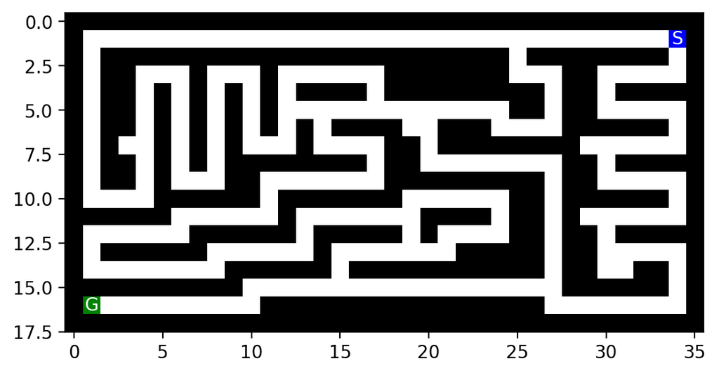

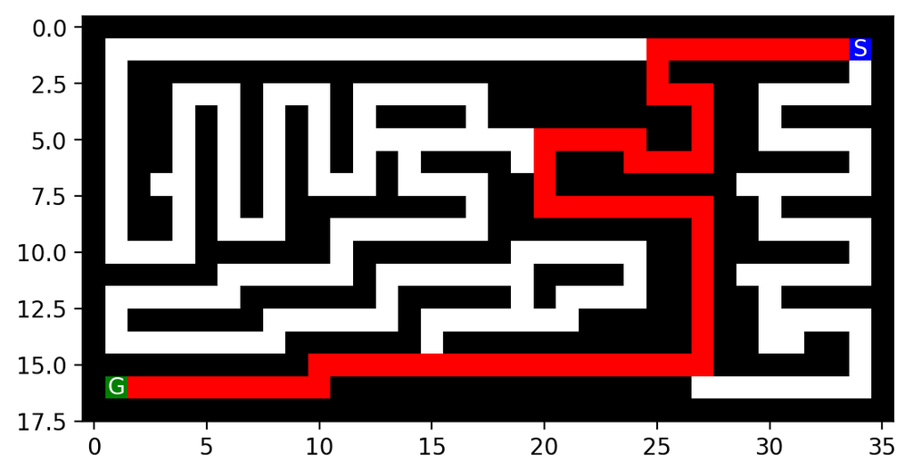

```
Path Cost: 68 ; Max Depth: 68 ; Max # of Nodes in Memory: 8 ; Max Frontier Size: 8 ; # of Nodes Expanded: 267
```

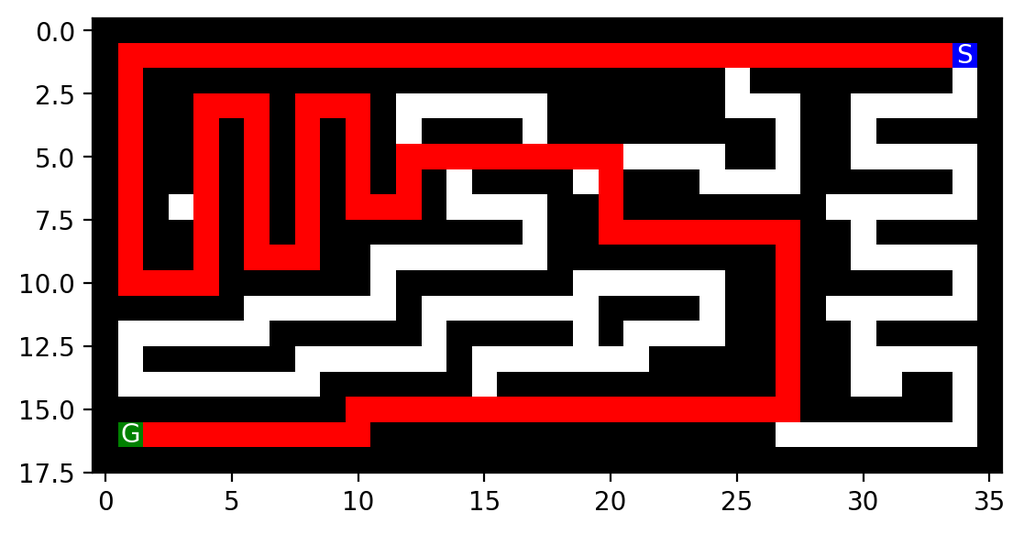

```
Path Cost: 130 ; Max Depth: 130 ; Max Node Memory: 8 ; Max Frontier: 8 ; Nodes Expanded: 146
```

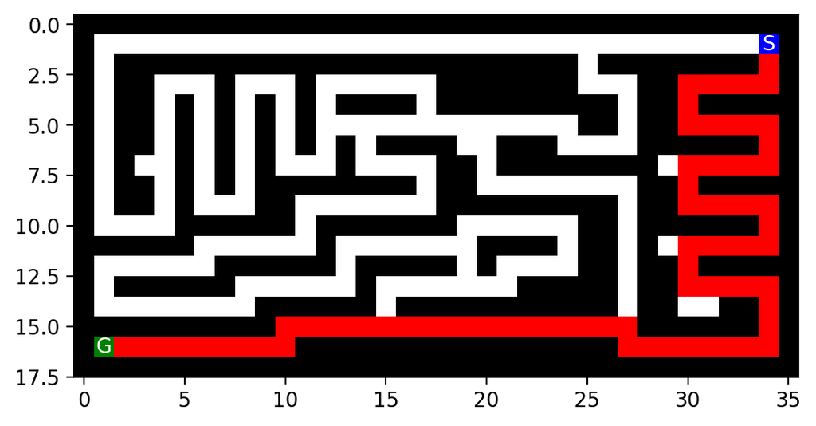

```
Path Cost: 74 ; Max Depth: 74 ; Max Node Memory: 4 ; Max Frontier: 4 ; Nodes Expanded: 78
```

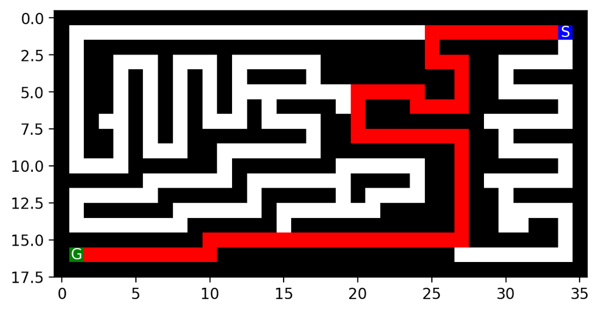

```
Path Cost: 68 ; Max Depth: 68 ; Max Node Memory: 8 ; Max Frontier: 8 ; Nodes Expanded: 222
```

```python
# Add code
with open("medium_maze.txt", "r") as f:
    maze_str = f.read()
maze = mh.parse_maze(maze_str)
print(maze_str)
mh.show_maze(maze)

# BFS
result = breadth_first_search(maze, mh.find_pos(maze, "S"), mh.find_pos(maze, "G"))
for node in result[0]:
    if maze[node.pos] not in ["S", "G"]:
        maze[node.pos] = "P"
mh.show_maze(maze)
print('Path Cost:', result[1], '; Max Depth:', result[2], '; Max # of Nodes in Memory:', result[3], '; Max Frontier Size:', result[4], '; # of Nodes Expanded:', result[5])

# DFS
resultdepth = depth_first_search(maze, mh.find_pos(maze, "S"), mh.find_pos(maze, "G"))
maze = mh.parse_maze(maze_str)
for node in resultdepth[0]:
    if maze[node.pos] not in ["S", "G"]:
        maze[node.pos] = "P"
mh.show_maze(maze)
print('Path Cost:', resultdepth[1], '; Max Depth:', resultdepth[2], '; Max Node Memory:', resultdepth[3], '; Max Frontier:', resultdepth[4], '; Nodes Expanded:', resultdepth[5])

# Greedy search
resultgreedy = greedy_best_first_search(maze, mh.find_pos(maze, "S"), mh.find_pos(maze, "G"))
maze = mh.parse_maze(maze_str)
for node in resultgreedy[0]:
    if maze[node.pos] not in ["S", "G"]:
        maze[node.pos] = "P"
mh.show_maze(maze)
print('Path Cost:', resultgreedy[1], '; Max Depth:', resultgreedy[2], '; Max Node Memory:', resultgreedy[3], '; Max Frontier:', resultgreedy[4], '; Nodes Expanded:', resultgreedy[5])

# a* search
resulta = a_breadth_first_search(maze, mh.find_pos(maze, "S"), mh.find_pos(maze, "G"))
maze = mh.parse_maze(maze_str)
for node in resulta[0]:
    if maze[node.pos] not in ["S", "G"]:
        maze[node.pos] = "P"
mh.show_maze(maze)
print('Path Cost:', resulta[1], '; Max Depth:', resulta[2], '; Max Node Memory:', resulta[3], '; Max Frontier:', resulta[4], '; Nodes Expanded:', resulta[5])
```

```python
# Table
results = [
    ['BFS', result[1], result[2], result[3], result[4], result[5]],
    ['DFS', resultdepth[1], resultdepth[2], resultdepth[3], resultdepth[4], resultdepth[5]],
    ['Greedy Best-First', resultgreedy[1], resultgreedy[2], resultgreedy[3], resultgreedy[4], resultgreedy[5]],
    ['A* Search', resulta[1], resulta[2], resulta[3], resulta[4], resulta[5]]
]

columns = ['Algorithm', 'Path Cost', 'Max Depth', 'Max Nodes in Memory', 'Max Frontier Size', 'Nodes Expanded']

table = tabulate(results, headers=columns, tablefmt='grid')
print("Medium Maze")
print(table)
```

```
Medium Maze
+-------------------+-------------+-------------+-----------------------+---------------------+------------------+
| Algorithm         |   Path Cost |   Max Depth |   Max Nodes in Memory |   Max Frontier Size |   Nodes Expanded |
+===================+=============+=============+=======================+=====================+==================+
| BFS               |          68 |          68 |                     8 |                   8 |              267 |
+-------------------+-------------+-------------+-----------------------+---------------------+------------------+
| DFS               |         130 |         130 |                     8 |                   8 |              146 |
+-------------------+-------------+-------------+-----------------------+---------------------+------------------+
| Greedy Best-First |          74 |          74 |                     4 |                   4 |               78 |
+-------------------+-------------+-------------+-----------------------+---------------------+------------------+
| A* Search         |          68 |          68 |                     8 |                   8 |              222 |
+-------------------+-------------+-------------+-----------------------+---------------------+------------------+
```

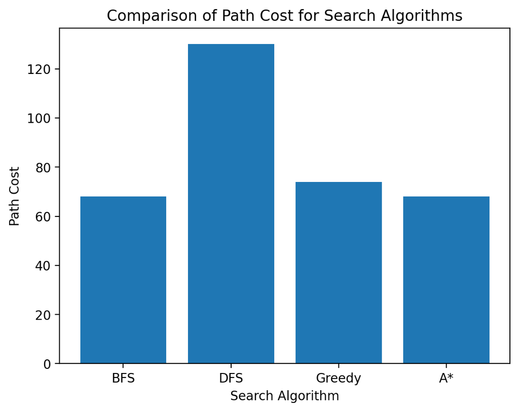

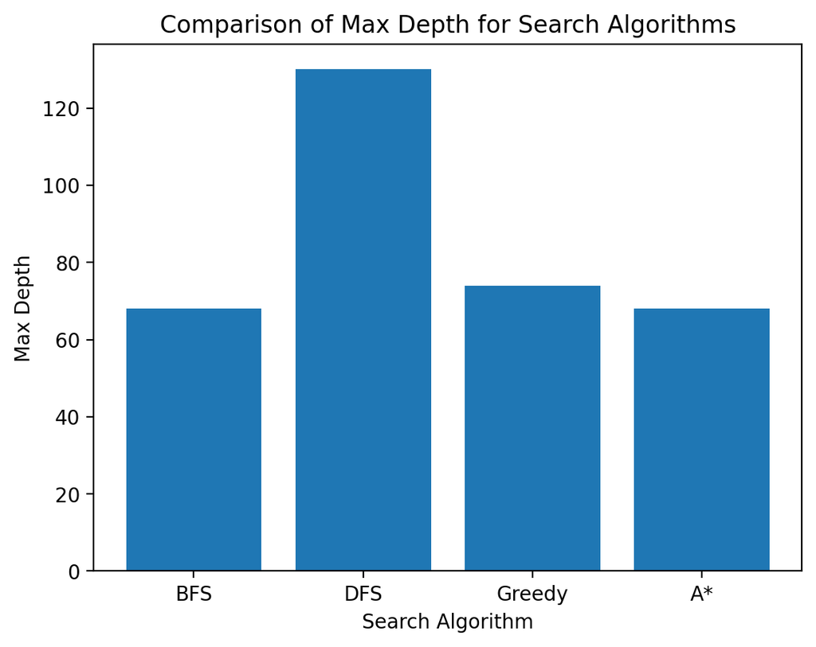

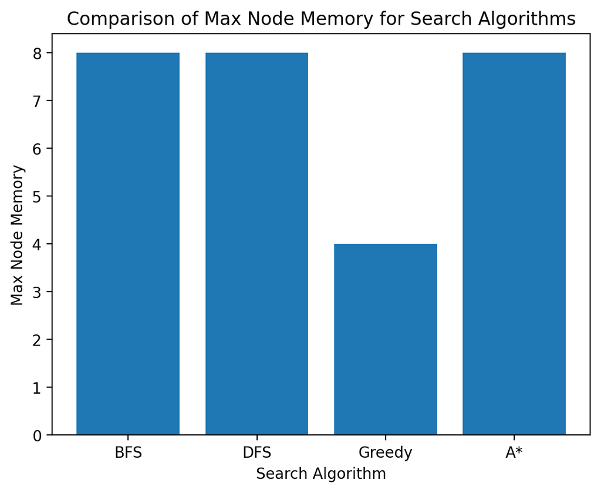

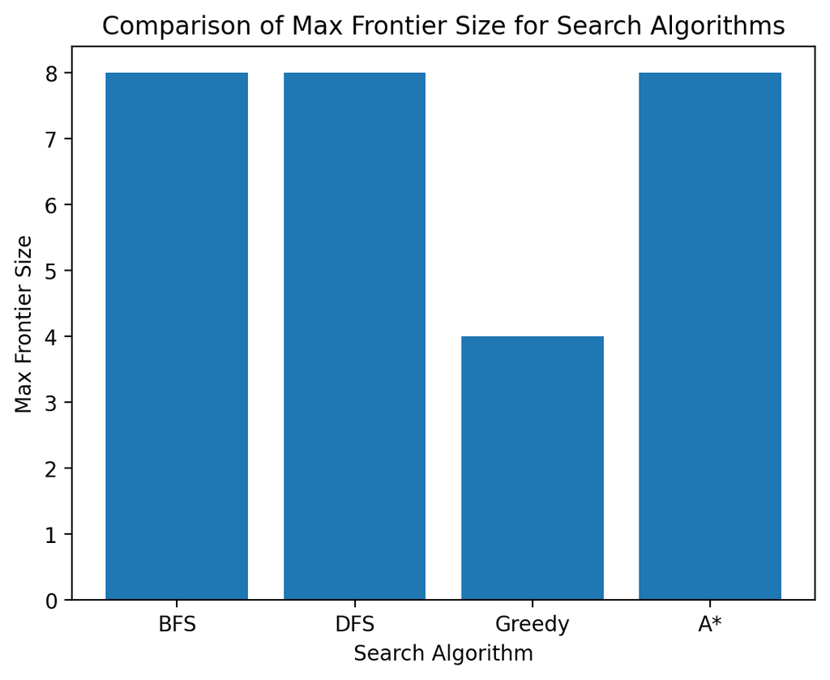

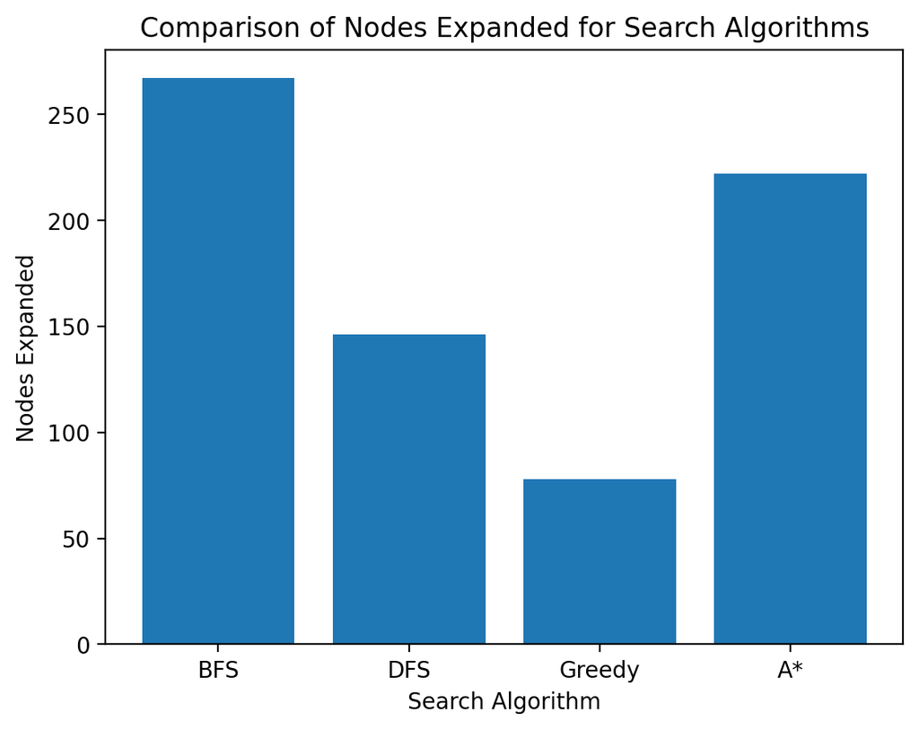

```python
# Generate the charts
path_costs = [result[1], resultdepth[1], resultgreedy[1], resulta[1]]
max_depths = [result[2], resultdepth[2], resultgreedy[2], resulta[2]]
max_node_memories = [result[3], resultdepth[3], resultgreedy[3], resulta[3]]
max_frontiers = [result[4], resultdepth[4], resultgreedy[4], resulta[4]]
nodes_expanded = [result[5], resultdepth[5], resultgreedy[5], resulta[5]]
metrics = {
    'Path Cost': path_costs,
    'Max Depth': max_depths,
    'Max Node Memory': max_node_memories,
    'Max Frontier Size': max_frontiers,
    'Nodes Expanded': nodes_expanded
}
for metric_name, values in metrics.items():
    plt.figure()
    plt.bar(algorithms, values)
    plt.title(f'Comparison of {metric_name} for Search Algorithms')
    plt.xlabel('Search Algorithm')
    plt.ylabel(metric_name)
    plt.show()
```

```
XXXXXXXXXXXXXXXXXXXXXXXXXXXXXXXXXXXXX
X       X X X           X   X     X X
X XXXXXXX X XXX X XXX XXX XXXXXXX X X
X       X       X X     X     X X   X
XXXXX XXXXX XXX X X X XXX XXXXX X XXX
X   X X X X   X X X X   X X   X X   X
X XXX X X X XXX XXXXX XXX X XXX XXX X
X       X     X   X   X     X X X   X
XXX XXXXXXXXX XXXXXXX XXX XXX X X X X
X             X       X X   X     X X
X X XXXXX X XXX X X XXX X XXX XXX X X
X X X     X X X X X     X   X X X X X
X X X XXXXXXX X XXXXXXXXX XXX X XXX X
X X X X     X   X     X     X   X   X
XXX XXX X XXXXX XXXXX XXX XXX XXXXX X
X     X X X     X X     X X   X X X X
X X X X X XXX XXX XXX XXX X X X X X X
X X X X X                 X X X     X
XXX XXXXXXX X X XXXXX XXX X XXX XXXXX
X       X X X X     X   X     X X   X
XXXXX X X XXXXXXXXX XXXXXXXXXXX X XXX
X   X X           X X     X   X X   X
X XXX XXXXX XXXXXXXXX XXXXX X X XXX X
X X   X      X        X     X       X
X X X XXXXX XXX X X X X XXXXXXXXXXXXX
X X X   X     X X X X       X   X X X
X X XXX XXX X X X XXXXXXXXX XXX X X X
X X   X X   X X X   X X   X X X     X
X XXX XXX XXXXX XXX X X XXXXX X XXXXX
X       X   X     X X     X   X X   X
XXX X XXXXX XXXXX XXX XXX X XXX X XXX
X X X X X X X X     X X   X X   X X X
X X XXX X X X X XXXXXXXXX X X X X X X
X   X   X   X                 X     X
X X X X XXX XXX XXXXXXX XXX XXX XXX X
XGX X X       X   X       X   X X  SX
XXXXXXXXXXXXXXXXXXXXXXXXXXXXXXXXXXXXX
```

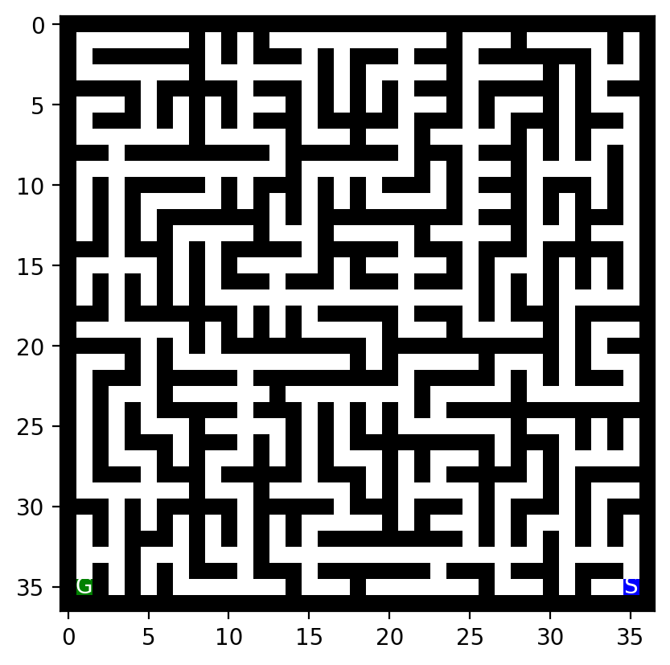

```
Path Cost: 210 ; Max Depth: 210 ; Max # of Nodes in Memory: 8 ; Max Frontier Size: 8 ; # of Nodes Expanded: 617
```

```
Path Cost: 210 ; Max Depth: 222 ; Max Node Memory: 38 ; Max Frontier: 38 ; Nodes Expanded: 390
```

```
Path Cost: 210 ; Max Depth: 210 ; Max Node Memory: 21 ; Max Frontier: 21 ; Nodes Expanded: 466
```

```
Path Cost: 210 ; Max Depth: 210 ; Max Node Memory: 12 ; Max Frontier: 12 ; Nodes Expanded: 549
```

```python
# Add code
with open("large_maze.txt", "r") as f:
    maze_str = f.read()
maze = mh.parse_maze(maze_str)
print(maze_str)
mh.show_maze(maze)

# BFS
result = breadth_first_search(maze, mh.find_pos(maze, "S"), mh.find_pos(maze, "G"))
for node in result[0]:
    if maze[node.pos] not in ["S", "G"]:
        maze[node.pos] = "P"
mh.show_maze(maze)
print('Path Cost:', result[1], '; Max Depth:', result[2], '; Max # of Nodes in Memory:', result[3], '; Max Frontier Size:', result[4], '; # of Nodes Expanded:', result[5])

# DFS
resultdepth = depth_first_search(maze, mh.find_pos(maze, "S"), mh.find_pos(maze, "G"))
maze = mh.parse_maze(maze_str)
for node in resultdepth[0]:
    if maze[node.pos] not in ["S", "G"]:
        maze[node.pos] = "P"
mh.show_maze(maze)
print('Path Cost:', resultdepth[1], '; Max Depth:', resultdepth[2], '; Max Node Memory:', resultdepth[3], '; Max Frontier:', resultdepth[4], '; Nodes Expanded:', resultdepth[5])

# Greedy search
resultgreedy = greedy_best_first_search(maze, mh.find_pos(maze, "S"), mh.find_pos(maze, "G"))
maze = mh.parse_maze(maze_str)
for node in resultgreedy[0]:
    if maze[node.pos] not in ["S", "G"]:
        maze[node.pos] = "P"
mh.show_maze(maze)
print('Path Cost:', resultgreedy[1], '; Max Depth:', resultgreedy[2], '; Max Node Memory:', resultgreedy[3], '; Max Frontier:', resultgreedy[4], '; Nodes Expanded:', resultgreedy[5])

# a* search
resulta = a_breadth_first_search(maze, mh.find_pos(maze, "S"), mh.find_pos(maze, "G"))
maze = mh.parse_maze(maze_str)
for node in resulta[0]:
    if maze[node.pos] not in ["S", "G"]:
        maze[node.pos] = "P"
mh.show_maze(maze)
print('Path Cost:', resulta[1], '; Max Depth:', resulta[2], '; Max Node Memory:', resulta[3], '; Max Frontier:', resulta[4], '; Nodes Expanded:', resulta[5])
```

[output not shown]

```python
# Table
results = [
    ['BFS', result[1], result[2], result[3], result[4], result[5]],
    ['DFS', resultdepth[1], resultdepth[2], resultdepth[3], resultdepth[4], resultdepth[5]],
    ['Greedy Best-First', resultgreedy[1], resultgreedy[2], resultgreedy[3], resultgreedy[4], resultgreedy[5]],
    ['A* Search', resulta[1], resulta[2], resulta[3], resulta[4], resulta[5]]
]

columns = ['Algorithm', 'Path Cost', 'Max Depth', 'Max Nodes in Memory', 'Max Frontier Size', 'Nodes Expanded']

table = tabulate(results, headers=columns, tablefmt='grid')
print("Large Maze")
print(table)
```

```
Large Maze
+-------------------+-------------+-------------+-----------------------+---------------------+------------------+
| Algorithm         |   Path Cost |   Max Depth |   Max Nodes in Memory |   Max Frontier Size |   Nodes Expanded |
+===================+=============+=============+=======================+=====================+==================+
| BFS               |         210 |         210 |                     8 |                   8 |              617 |
+-------------------+-------------+-------------+-----------------------+---------------------+------------------+
| DFS               |         210 |         222 |                    38 |                  38 |              390 |
+-------------------+-------------+-------------+-----------------------+---------------------+------------------+
| Greedy Best-First |         210 |         210 |                    21 |                  21 |              466 |
+-------------------+-------------+-------------+-----------------------+---------------------+------------------+
| A* Search         |         210 |         210 |                    12 |                  12 |              549 |
+-------------------+-------------+-------------+-----------------------+---------------------+------------------+
```

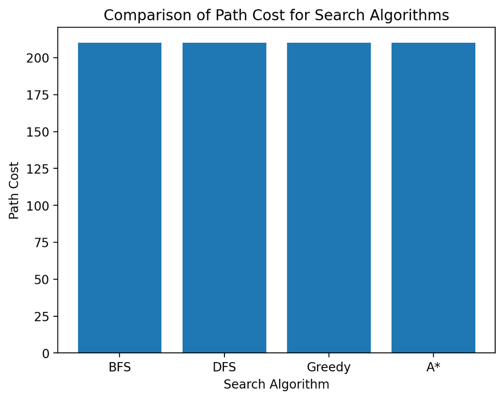

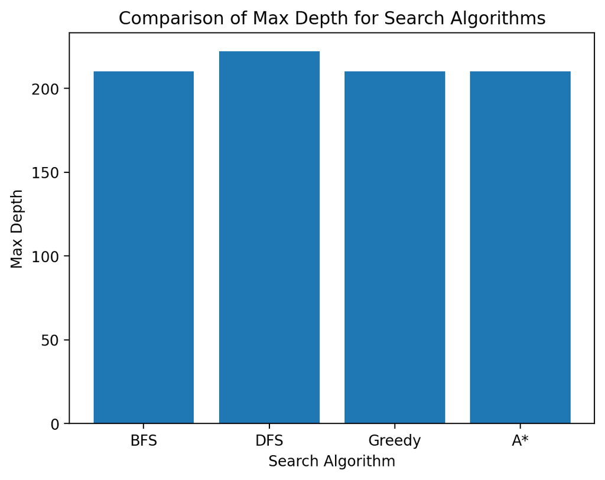

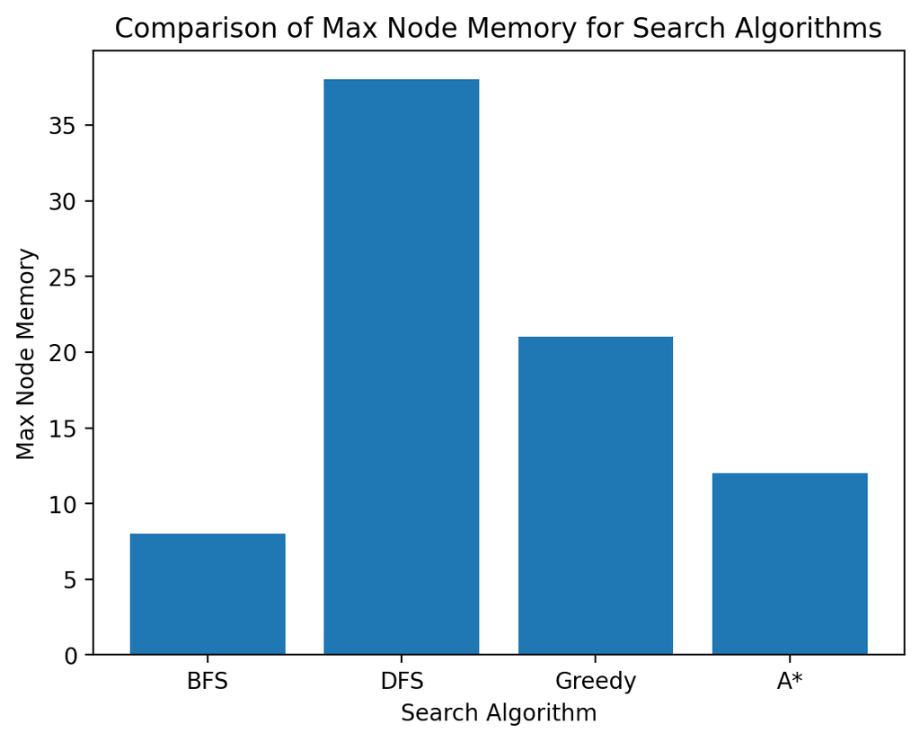

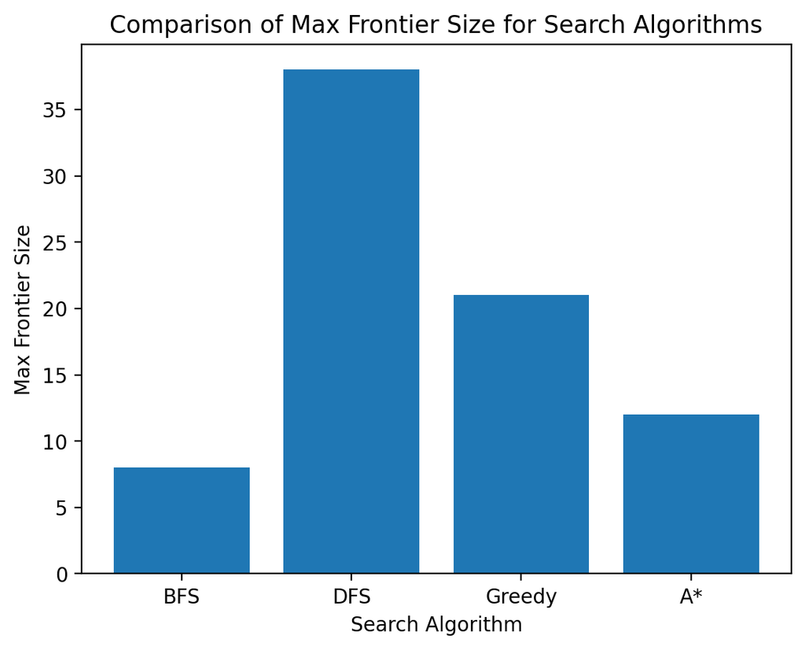

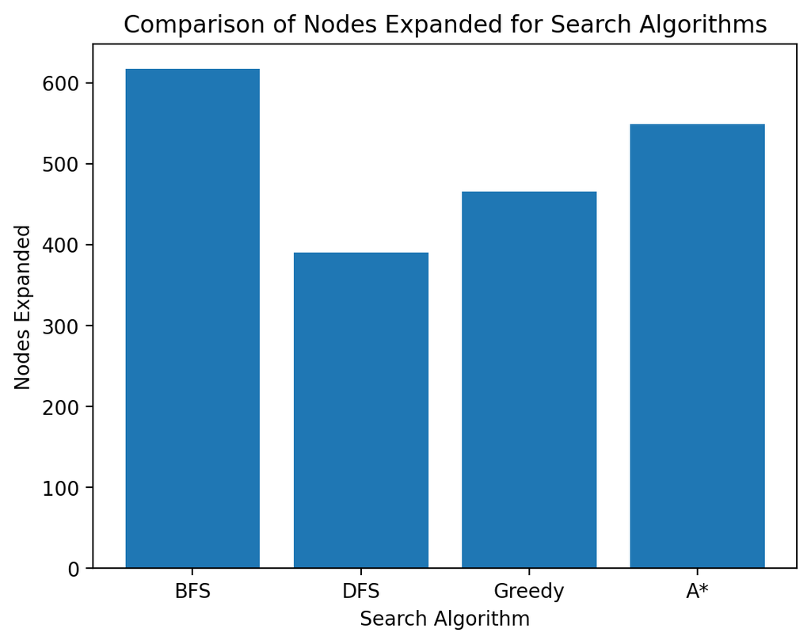

```python
# Generate the charts
path_costs = [result[1], resultdepth[1], resultgreedy[1], resulta[1]]
max_depths = [result[2], resultdepth[2], resultgreedy[2], resulta[2]]
max_node_memories = [result[3], resultdepth[3], resultgreedy[3], resulta[3]]
max_frontiers = [result[4], resultdepth[4], resultgreedy[4], resulta[4]]
nodes_expanded = [result[5], resultdepth[5], resultgreedy[5], resulta[5]]
metrics = {
    'Path Cost': path_costs,
    'Max Depth': max_depths,
    'Max Node Memory': max_node_memories,
    'Max Frontier Size': max_frontiers,
    'Nodes Expanded': nodes_expanded
}
for metric_name, values in metrics.items():
    plt.figure()
    plt.bar(algorithms, values)
    plt.title(f'Comparison of {metric_name} for Search Algorithms')
    plt.xlabel('Search Algorithm')
    plt.ylabel(metric_name)
    plt.show()
```

```
XXXXXXXXXXXXXXXXXXXXXXXXXXXXXXXXXXXXX
X                                  SX
X            X                      X
X            X                      X
X            X                      X
X            X                      X
X            X                      X
X            X      X               X
X            X      X               X
X            X      X               X
X            X      X               X
X            X      X               X
X            X      X               X
X            X      X               X
XXXXXXXXXXXXXX      XXXXXXXXXXXXXXXXX
X            X                      X
X            X                      X
X            X                      X
X                                   X
X                                   X
X                                   X
XG                                  X
XXXXXXXXXXXXXXXXXXXXXXXXXXXXXXXXXXXXX
```

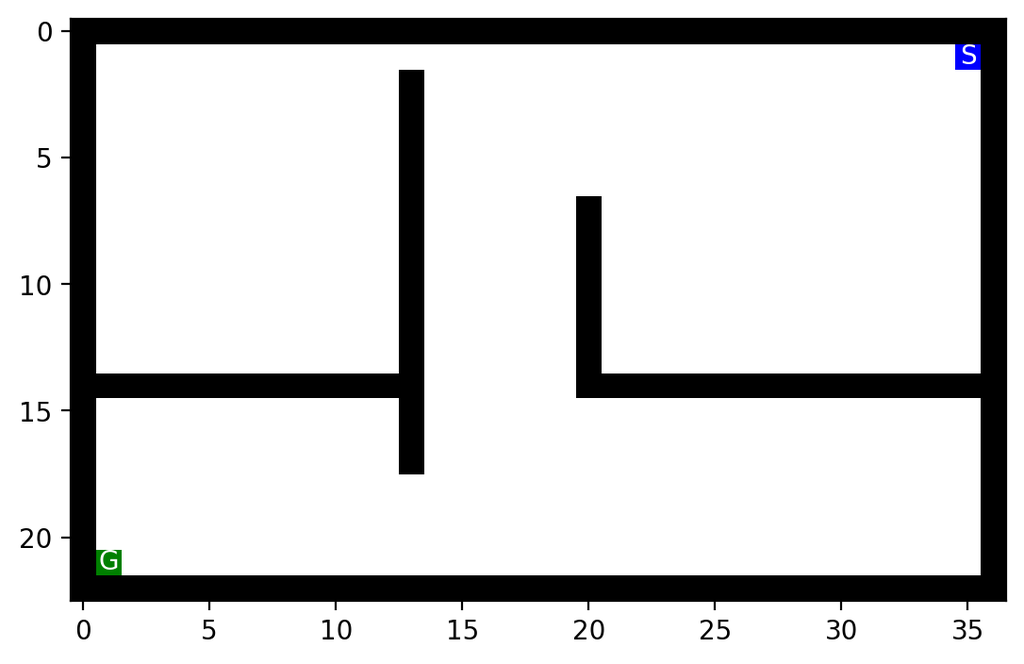

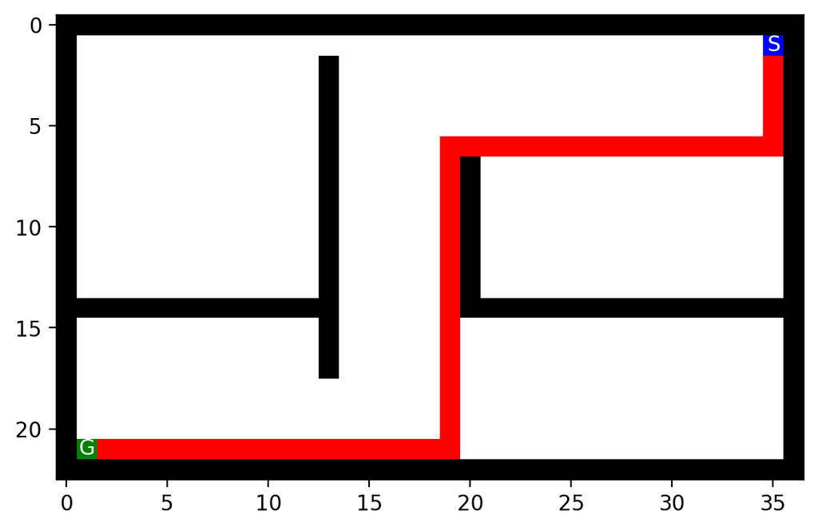

```
Path Cost: 54 ; Max Depth: 54 ; Max # of Nodes in Memory: 25 ; Max Frontier Size: 25 ; # of Nodes Expanded: 679
```

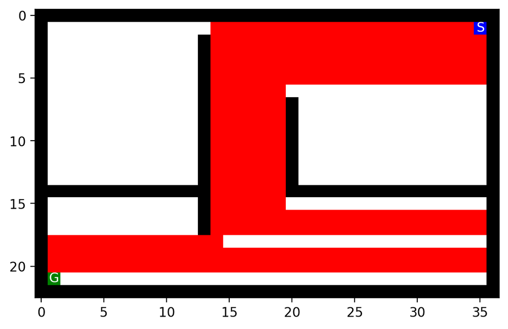

```
Path Cost: 298 ; Max Depth: 298 ; Max Node Memory: 84 ; Max Frontier: 84 ; Nodes Expanded: 576
```

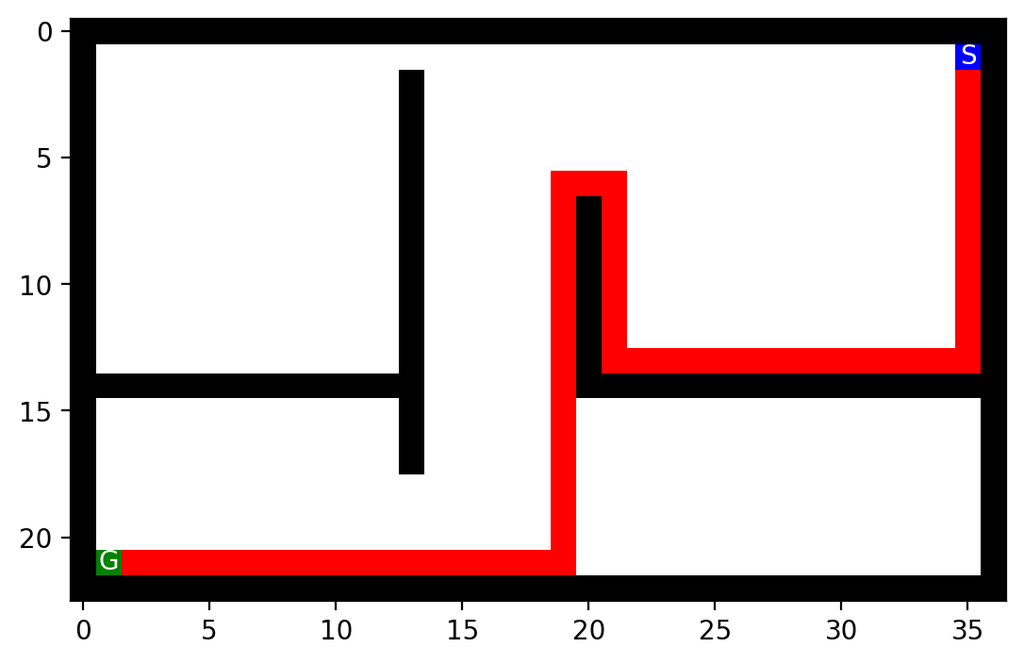

```
Path Cost: 68 ; Max Depth: 68 ; Max Node Memory: 65 ; Max Frontier: 65 ; Nodes Expanded: 89
```

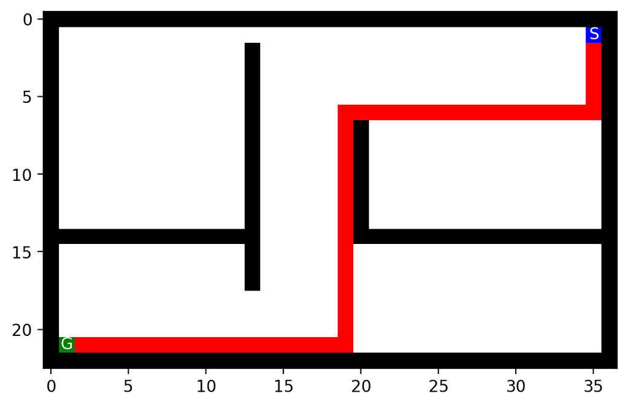

```
Path Cost: 54 ; Max Depth: 54 ; Max Node Memory: 25 ; Max Frontier: 25 ; Nodes Expanded: 534
```

```python
# Add code
with open("open_maze.txt", "r") as f:
    maze_str = f.read()
maze = mh.parse_maze(maze_str)
print(maze_str)
mh.show_maze(maze)

# BFS
result = breadth_first_search(maze, mh.find_pos(maze, "S"), mh.find_pos(maze, "G"))
for node in result[0]:
    if maze[node.pos] not in ["S", "G"]:
        maze[node.pos] = "P"
mh.show_maze(maze)
print('Path Cost:', result[1], '; Max Depth:', result[2], '; Max # of Nodes in Memory:', result[3], '; Max Frontier Size:', result[4], '; # of Nodes Expanded:', result[5])

# DFS
resultdepth = depth_first_search(maze, mh.find_pos(maze, "S"), mh.find_pos(maze, "G"))
maze = mh.parse_maze(maze_str)
for node in resultdepth[0]:
    if maze[node.pos] not in ["S", "G"]:
        maze[node.pos] = "P"
mh.show_maze(maze)
print('Path Cost:', resultdepth[1], '; Max Depth:', resultdepth[2], '; Max Node Memory:', resultdepth[3], '; Max Frontier:', resultdepth[4], '; Nodes Expanded:', resultdepth[5])

# Greedy search
resultgreedy = greedy_best_first_search(maze, mh.find_pos(maze, "S"), mh.find_pos(maze, "G"))
maze = mh.parse_maze(maze_str)
for node in resultgreedy[0]:
    if maze[node.pos] not in ["S", "G"]:
        maze[node.pos] = "P"
mh.show_maze(maze)
print('Path Cost:', resultgreedy[1], '; Max Depth:', resultgreedy[2], '; Max Node Memory:', resultgreedy[3], '; Max Frontier:', resultgreedy[4], '; Nodes Expanded:', resultgreedy[5])

# a* search
resulta = a_breadth_first_search(maze, mh.find_pos(maze, "S"), mh.find_pos(maze, "G"))
maze = mh.parse_maze(maze_str)
for node in resulta[0]:
    if maze[node.pos] not in ["S", "G"]:
        maze[node.pos] = "P"
mh.show_maze(maze)
print('Path Cost:', resulta[1], '; Max Depth:', resulta[2], '; Max Node Memory:', resulta[3], '; Max Frontier:', resulta[4], '; Nodes Expanded:', resulta[5])
```

```python
# Table
results = [
    ['BFS', result[1], result[2], result[3], result[4], result[5]],
    ['DFS', resultdepth[1], resultdepth[2], resultdepth[3], resultdepth[4], resultdepth[5]],
    ['Greedy Best-First', resultgreedy[1], resultgreedy[2], resultgreedy[3], resultgreedy[4], resultgreedy[5]],
    ['A* Search', resulta[1], resulta[2], resulta[3], resulta[4], resulta[5]]
]

columns = ['Algorithm', 'Path Cost', 'Max Depth', 'Max Nodes in Memory', 'Max Frontier Size', 'Nodes Expanded']

table = tabulate(results, headers=columns, tablefmt='grid')
print("Open Maze")
print(table)
```

```
Open Maze
+-------------------+-------------+-------------+-----------------------+---------------------+------------------+
| Algorithm         |   Path Cost |   Max Depth |   Max Nodes in Memory |   Max Frontier Size |   Nodes Expanded |
+===================+=============+=============+=======================+=====================+==================+
| BFS               |          54 |          54 |                    25 |                  25 |              679 |
+-------------------+-------------+-------------+-----------------------+---------------------+------------------+
| DFS               |         298 |         298 |                    84 |                  84 |              576 |
+-------------------+-------------+-------------+-----------------------+---------------------+------------------+
| Greedy Best-First |          68 |          68 |                    65 |                  65 |               89 |
+-------------------+-------------+-------------+-----------------------+---------------------+------------------+
| A* Search         |          54 |          54 |                    25 |                  25 |              534 |
+-------------------+-------------+-------------+-----------------------+---------------------+------------------+
```